# Biostatistical Computing, PHC 6068

R package

Zhiguang Huo (Caleb)

Monday Sep 23, 2019

# Install R packages

- from CRAN, 14,925 packages, up to 9/17/2019.

```r
install.packages("mclust")
```

- from Bioconductor: 1,741 packages, 9/17/2019.

```r
## try http:// if https:// URLs are not supported
if (!requireNamespace("BiocManager", quietly = TRUE))
    install.packages("BiocManager")

BiocManager::install("impute")
```

- .gz.tar zipped file.

```r
install.packages("mclust_5.3.tar",repos=NULL,type="source")
```

- package folder.

```r
# in R:
system("R CMD INSTALL mclust")
#command line: R CMD INSTALL mclust
```

- github.

```r
library(devtools)
install_github("cran/mclust")
```

# Why R package

- Share with others, if your code is in a package, any R user can easily download it, install it and learn how to use it.
- It is about saving yourself time. Organizing code in a package makes your life easier because packages come with conventions.

# Basic structure of an R Package

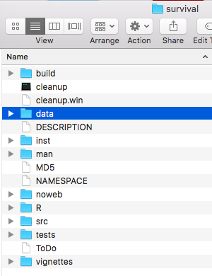

- Using R survival package as an example:
  - DESCRIPTION: metadata, basic information, dependency…
  - NAMESPACE: control the imported and exported objects.
  - R: R code
  - man: manual
  - src: other language (c, java…)
  - test: test validity of your functions
  - vignettes: an overall description of your package
  - ToDo: to do list

# Play with survival package

- library a package

```r
library(survival)
```

- help file about the package

```r
help(package = 'survival')
```

- help file about one function

```r
?coxph
```

- check out vignettes

```r
browseVignettes("survival")
```

# Structure of R package

- R/: the most important directory is R/
- DESCRIPTION: basic information, dependency.
- Documentation: if you want other people (including future-you!) to understand how to use the functions in your package, you’ll need to document them.
- Vignettes: function documentation describes the nit-picky details of every function in your package.They’re long-form documents that show how to combine multiple parts of your package to solve real problems.
- Tests: to ensure your package works as designed (and continues to work as you make changes), it’s essential to write unit tests which define correct behaviour, and alert you when functions break.
- Namespace: to play nicely with others, your package needs to define what functions it makes available to other packages and what functions it requires from other packages.
- data/: this directory allows you to include data with your package.
- src/: other programming languages.

# DESCRIPTION

The job of the DESCRIPTION file is to store important metadata about your package. Every package must have a DESCRIPTION. In fact, it’s the defining feature of a package.

- LazyLoad, if yes delays the loading of functions until they are required.
- Title and description.
- Author: who are you.
- Dependencies.
- License.
- Version.

# DESCRIPTION License

- GPL-2/GPL-3: anyone who distributes modified versions of your code (derivative works) must also make the source code
  - open source,
  - GPL-compatible.
- MIT: This is a simple and permissive license.
  - They are extremely short and essentially say “do whatever you want with this, just don’t sue me.”
- CC0. It relinquishes all your rights on the code and data so that it can be freely used by anyone for any purpose.
- Apache:
  - “do whatever you want with this, just don’t sue me” but does so with many more words
  - Contains patent license and retaliation clause to prevent patents from encumbering the software project
- Many others

# DESCRIPTION Version

Formally, an R package version is a sequence of at least two integers separated by either . or -. For example, 1.0 and 0.9.1-10 are valid versions, but 1 or 1.0-devel are not.

- A released version number consists of three numbers, ... For version number 1.9.2, 1 is the major number, 9 is the minor number, and 2 is the patch number. Never use versions like 1.0, instead always spell out the three components, 1.0.0.
- An in-development package has a fourth component: the development version. This should start at 9000. For example, the first version of the package should be 0.0.0.9000.

# The namespace file in R package

- Specifies which functions will be visible to users.
- Specifies which functions are internal funciton, for which you don’t want the users to see and use.
- Specifies how to interaction with other programming language (e.g., c++)
- Specifies how to your package depends on other packages
- Don’t need to revise the namespace file, will be managed by devtools.

# Namespace

- :: to specify namespace

```
base::dim
```

- Namespace protect the internal functions being overwritten by functions from other packages/global environment.

```
nrow
dim(mtcars)
dim <- function(x) c(1, 1)
dim(mtcars)
nrow(mtcars)
```

# Man (for manual)

- Documentation is one of the most important aspects of a good package. Without it, users won’t know how to use your package.
- Documentation is also useful for future-you (so you remember what your functions were supposed to do), and for developers extending your package.
- R provides a standard way of documenting the objects in a package: you write .Rd files in the man/ directory. These files use a custom syntax, loosely based on LaTeX, and are rendered to HTML, plain text and pdf for viewing.

# Devtools, starting from sketches.

Red color indicates essential steps

1. devtools::create() create an new R package
2. Copy your R code in inside R folder
3. formatR::tidy_dir() clean up the code
4. Add documentation in R code
5. devtools::document() generate R documentation
6. usethis::use_data() prepare external data
7. usethis::use_testthat() prepare test functions
8. devtools::test() preform test
9. usethis::use_vignette() generate vignettes
10. devtools::check() check the package
11. devtools::build() build the package
12. devtools::install() install the package
13. others

# 1. devtools::create() create an new R package

```r
## set working directory to be Desktop
WD <- '~/Desktop'
setwd(WD)

devtools::create("GatorPKG")
WD2 <- '~/Desktop/GatorPKG'
setwd(WD2)
```

# 2. Copy your R code in inside R folder

- f.R

```r
##' @export
f <- function(x, y) x + y
```

- g.R

```r
##' @export
g <- function(x, y) x - y
```

- h.R

```r
##' @export
h <- function(x, y) f(x,y) * g(x,y)
```

- all.R

```r
##' @export
all <- function(x, y){
  f0 <- f(x,y)
  g0 <- g(x,y)
  h0 <- h(x,y)
  list(f=f0, g=g0, h=h0)
}
```

# 3. formatR::tidy dir() clean up the code

```r
setwd(WD2)
## make the code neat
formatR::tidy_dir("R")
```

# 4. Add documentation in R code

- f.R

```r
##' Add up two numbers (Description)
##'
##' We want to add up two numbers, blalala... (Details)
##' @title add two numbers
##' @param x first number
##' @param y second number
##' @return sum of two numbers
##' @author Caleb
##' @export
##' @examples
##' f(1,2)
f <- function(x, y) x + y
```

- g.R

```r
##' Subtract two numbers (Description)
##'
##' We want to Subtract two numbers, blalala... (Details)
##' @title Subtract two numbers
##' @param x first number
##' @param y second number
##' @return x - y
##' @author Caleb
##' @export
##' @examples
##' g(2,1)
g <- function(x, y) x - y
```

- h.R

```r
##' Complex operations on two numbers (Description)
##'
##' We want to do some complex operations on two numbers, blalala... (Details)
##' @title Very complex operation of two numbers
##' @param x first number
##' @param y second number
##' @return (x - y)(x + y)
##' @author Caleb
##' @export
##' @examples
##' h(3,2)
h <- function(x, y) f(x,y) * g(x,y)
```

- all.R

```r
##' Return f,g,h (Description)
##'
##' We want to return f,g,h , blalala... (Details)
##' @title return all
##' @param x first number
##' @param y second number
##' @return A list of f, g, and h.
##' \item{f}{Results for adding}
##' \item{g}{Results for subtracting}
##' \item{h}{Complex Result}
##' @author Caleb
##' @export
##' @examples
##' all(3,2)
all <- function(x, y){
  f0 <- f(x,y)
  g0 <- g(x,y)
  h0 <- h(x,y)
  list(f=f0, g=g0, h=h0)
}
```

# 5. devtools::document() generate R documentation

```r
devtools::document() ## default argument is pkg = ".", current working directory
```

Change:

- NAMESPACE is updated
- man folder is created

# 6. usethis::use_data() prepare external data

```r
xxxx <- sample(1000)
usethis::use_data(xxxx)
```

Change:

- data folder
- after install the package, do the following:

```
data(xxxx)
```

# 6. documenting external data

- no need to export external data

xxxx.R

```r
#' Prices of 50,000 round cut diamonds.
#'
#' A dataset containing the prices and other attributes of almost 54,000
#' diamonds.
#'
#' @format A data frame with 53940 rows and 10 variables:
#' \describe{
#'   \item{price}{price, in US dollars}
#'   \item{carat}{weight of the diamond, in carats}
#'   ...
#' }
#' @source \url{http://www.diamondse.info/}
"xxxx"
```

# 6. internal data

- Internal data: These objects are only available within the package.
- Will be saved as sysdata.rda in R/
- No documentation
- Good to put the raw code in data-raw/ for reproducibility purpose

```r
yyyy <- sample(1000)
usethis::use_data(yyyy, internal = TRUE)
```

# 7. usethis::use_testthat() prepare test functions

- create test functions

```r
usethis::use_testthat() ## default argument is pkg = ".", current working directory
```

- actual test function (e.g. testthat/testf.R)

```r
test_that("test if f function is correct", {
    expect_equal(f(1,1), 2)
  }
)

test_that("test if f function is correct", {
    expect_equal(f(1,4), 2)
  }
)
```

# 8. devtools::test() preform test

- perform test

```r
devtools::test() ## default argument is pkg = ".", current working directory
```

# 9. usethis::use_vignette() generate vignettes

- browse all Vignettes

```r
browseVignettes()
```

- create our own Vignettes

```r
setwd(WD2)
usethis::use_vignette("Gators")
```

# 10. devtools::check() check the package

- check the package

```r
setwd(WD2)
devtools::check() ## default argument is pkg = ".", current working directory
```

# 11. devtools::build() build the package

- build() will generate .tar.gz package

```r
## build the package
devtools::build() ## default argument is pkg = ".", current working directory
```

- an inst folder will be created, which contains your vignettes.

# 12. devtools::install() install the package

- install the package

```r
devtools::install() ## default argument is pkg = ".", current working directory
devtools::install(build_vignettes = TRUE) ## also build the vignettes
```

- remove the package

```r
remove.packages("GatorPKG")
```

- install the pacakge again

```r
install.packages(file.path("~/Desktop","GatorPKG_0.0.0.9000.tar.gz"),repos=NULL,type="source") ## directly with vignettes
```

# 13, Package checks

- R CMD check

```r
system("R CMD check ~/Desktop/GatorPKG_0.0.0.9000.tar.gz")
```

This is equivalent to running the following in linux.

```
R CMD check ~/Desktop/GatorPKG_0.0.0.9000.tar.gz
```

# 14, others (internal function)

- internal function: you want to use internally but don’t want other people to see it.
- If we do not use ##` @export, the function will become a internal function

# 15a, others (depend on other packages)

- DESCRIPTION file Depends: R (>= 3.6.0), survival

```
Package: GatorPKG
Title: What the Package Does (one line, title case)
Version: 0.0.0.9000
Authors@R: person("First", "Last", email = "first.last@example.com", role = c("aut", "cre"))
Description: What the package does (one paragraph).
Depends: R (>= 3.6.0), survival
License: What license is it under?
Encoding: UTF-8
LazyData: true
RoxygenNote: 6.1.1
```

- change your function f.R to depend on coxph

```r
##' Add up two numbers (Description)
##'
##' We want to add up two numbers, blalala... (Details)
##' @title add two numbers
##' @param x first number
##' @param y second number
##' @return sum of two numbers
##' @author Caleb
##' @export
##' @examples
##' f(1,2)
f <- function(x, y){
  print(head(coxph))
  x + y
}
```

- all visible functions in the survival package will become available.

# 15b, others (depend on other packages)

What if you do not want to load the entire dependent package, but only certain functions

- Use @import in your function
- Don’t need to declare dependency in DESCRIPTION

```r
##' Add up two numbers (Description)
##'
##' We want to add up two numbers, blalala... (Details)
##' @title add two numbers
##' @param x first number
##' @param y second number
##' @return sum of two numbers
##' @author Caleb
##' @import survival
##' @export
##' @examples
##' f(1,2)
f <- function(x, y){
  print(head(coxph))
  x + y
}
```

- update namespace

```r
devtools::document()
```

- reinstall the package

Your function depends on the external package, but the external package is not loaded.

# 16, others (R package and GitHub)

- GitHub is a great open platform to host R packages
  - Apply for a github acccount
  - https://github.com
  - Free GitHub pro account (GitHub Education): requires scanning of the UF ID card.
- Play with the following git tutorials (HW)
  - https://www.codecademy.com/learn/learn-git

# References

- http://adv-r.had.co.nz
- https://exygy.com/which-license-should-i-use-mit-vs-apache-vs-gpl/